# Demo 13 | Spatial Regression: Error and Lag Models

Peter Kedron¹

2026-11-21

¹ Department of Geography, University of California Santa Barbara

Version 1.0 | First Created 2026-11-21 | Updated 2026-11-21

# 1. Introduction

A regression fit to geographic data often leaves behind residuals that cluster on the map.  
Spatial clustering of regression model residuals indicates that neighboring places are missed by the model in the same direction. When that happens, the independent errors assumption required to use ordinary least squares (OLS) is violated. Standard errors and p-values from the regression fitting can no longer be trusted, and if the missing spatial influence is related to the predictors, neither can its coefficients.

Finding the problem is only the first step. This demonstration takes the next step. Here we fits regression models that **represent the spatial dependence directly** and compare them with OLS. There are two basic ways to do this, and they rest on different ideas about why neighboring places resemble each other.

- In a **spatial error model**, neighbors share influences the model does not measure. The dependence lives in the error term.
- In a **spatial lag model**, the outcome in one place depends on the outcome in neighboring places. The dependence is part of the process itself, and a change in one place spills over to its neighbors.

The running example is a regression of the 2024 presidential vote across the counties of the Upper Midwest. We will:

- **Confirm** that the OLS residuals are spatially dependent.
- **Diagnose** which form of dependence the data support, using Lagrange multiplier tests, and check whether state differences can absorb it.
- **Estimate** a spatial error model and a spatial lag model, and compare their coefficients, fit, and residuals with OLS.
- **Interpret** the spatial lag model correctly, by separating the **direct, indirect, and total effects** of each predictor.

**Keywords:** spatial error model, spatial lag model, Lagrange multiplier tests, AIC, spatial multiplier, direct and indirect effects

# 2. Study Region, Data, and Model

## 2.1 Study Region

The study region is the Upper Midwest: the 242 counties of Michigan, Wisconsin, and Minnesota. These **core** counties are the ones we describe and report on. Around them is a **guard region** of 39 counties in IA, IL, IN, ND, OH, SD: every county outside the three states that shares a boundary or a corner with a core county. A study region cut from a larger map has artificial edges, and without the guard region a county on the Iowa border would have neighbors only to the north. The guard counties give the border counties complete sets of neighbors.

All of the models in this demonstration are fit to the full set of 281 counties, so that every county, including the guard counties, has an observed outcome and a residual that its neighbors can be compared with. Maps show the guard counties faded.

The **response variable** is the **Democratic share (`dem_share24`)**: Harris’s votes divided by the votes for Harris and Trump, times 100. Figure 1 maps it.

Two files are provided in this folder:

- **Upper Midwest counties (`midwest-election-2024.gpkg`):** the 281 counties of the study region, projected to NAD83 / Conus Albers (EPSG:5070, meters). The `counties` layer holds one polygon per county with its FIPS code (`fips`), state (`state_abb`), name (`county`), role (`role`: `core` or `guard`), the response variable, and the county characteristics. The `background` layer holds the surrounding U.S. states and Canadian provinces, for the maps only.
- **Codebook (`midwest-election-2024-variables.csv`):** the description, units, source, and motivating research for every variable in the `counties` layer.

The data are a regional extract of a national county-level file that joins 2024 presidential election results, compiled from the MIT Election Data and Science Lab, to county characteristics from federal and research sources, about half of them from the American Community Survey (2019–2023).

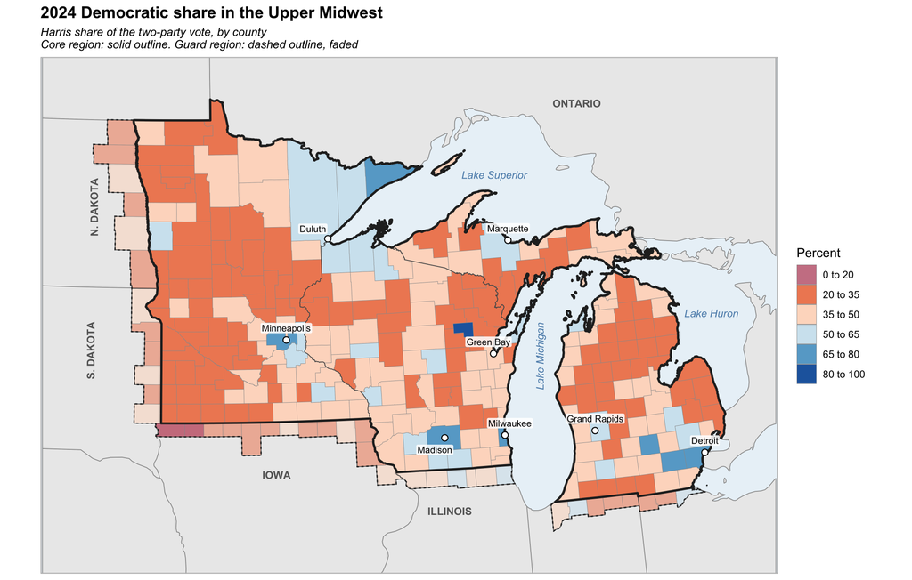

```r
# Load the county polygons (core and guard), the background layer, and the codebook
study_area <- st_read(data_file, layer = "counties", quiet = TRUE) %>%
  mutate(name = paste0(county, ", ", state_abb),
         role = factor(role, levels = c("core", "guard"))) %>%
  arrange(role, fips)
background <- st_read(data_file, layer = "background", quiet = TRUE)
codebook <- read.csv(file.path(data_dir, "midwest-election-2024-variables.csv"))

# Name the rows by FIPS code so the spatial functions can check the county order (spChk = TRUE)
rownames(study_area) <- study_area$fips
```

Figure 1: The response variable, the 2024 Democratic share of the two-party vote, by county. The 242 core counties are inside the solid outline; the 39 guard counties are faded, inside the dashed outline.

## 2.2 The Model

The model relates the Democratic share to five county characteristics, each chosen to test a hypothesis about how the Upper Midwest votes (Table 1).

| Predictor | Units | Hypothesis | Expected sign |
| --- | --- | --- | --- |
| White non-college share (`white_nocollege_pct`) | % | The education divide among white voters is a central political fault line. | Negative |
| Manufacturing share (`manuf_pct`) | % | Places exposed to deindustrialization and trade competition shifted right. | Negative |
| Log population density (`log_pop_density`) | log persons/km² | The urban–rural divide is among the strongest predictors of partisanship. | Positive |
| Median age (`median_age`) | years | Older places lean Republican. | Negative |
| Unemployment change (`unemp_change`) | percentage points | Voters punish the incumbent party when the economy worsens (2020–2023). | Negative |

Table 1: The five predictors, the hypothesis behind each, and the sign expected before fitting the model.

We fit the model by OLS. Its other assumptions (linearity, normality, and equal variance) are not the subject of this demonstration; we focus on independence.

```r
# Build the formula once, from the vector of predictor names
model_formula <- reformulate(predictors, response = "dem_share24")

# OLS on all counties (core and guard)
ols <- lm(model_formula, data = study_area, na.action = na.fail)
```

The five predictors account for 68 percent of the county-to-county variation in the Democratic share (adjusted $R^2 =$ 0.67).

## 2.3 Neighbors and the OLS Residuals

Every spatial model needs a definition of who is a neighbor, recorded in a **spatial weights matrix** $W$. We use **queen contiguity**: two counties are neighbors if their boundaries touch at any point. The weights are **row-standardized**, so each row of $W$ sums to 1 and multiplying a variable by $W$ gives each county the **average value among its neighbors**, the variable’s **spatial lag**. The same $W$ is used for every test and model below; the results depend on that choice.

```r
# Queen-contiguity neighbors for the whole study area (core and guard)
nb_queen <- poly2nb(study_area, queen = TRUE, row.names = study_area$fips)

# Row-standardized weights: each county's neighbors share its weight equally
lw_queen <- nb2listw(nb_queen, style = "W")
```

The question that motivates spatial regression is whether the OLS residuals are spatially dependent. `lm.morantest()` computes Moran’s I for the residuals of a fitted model, with the expected value and variance adjusted for the fact that residuals must sum to zero and be uncorrelated with the predictors.

```r
# Moran's I of the OLS residuals
moran_ols <- lm.morantest(ols, lw_queen, alternative = "two.sided", spChk = TRUE)
```

The OLS residuals have a Moran’s I of 0.501 ($p$ < 0.001): counties that the model misses in one direction sit next to counties it misses in the same direction. Figure 2 shows where.

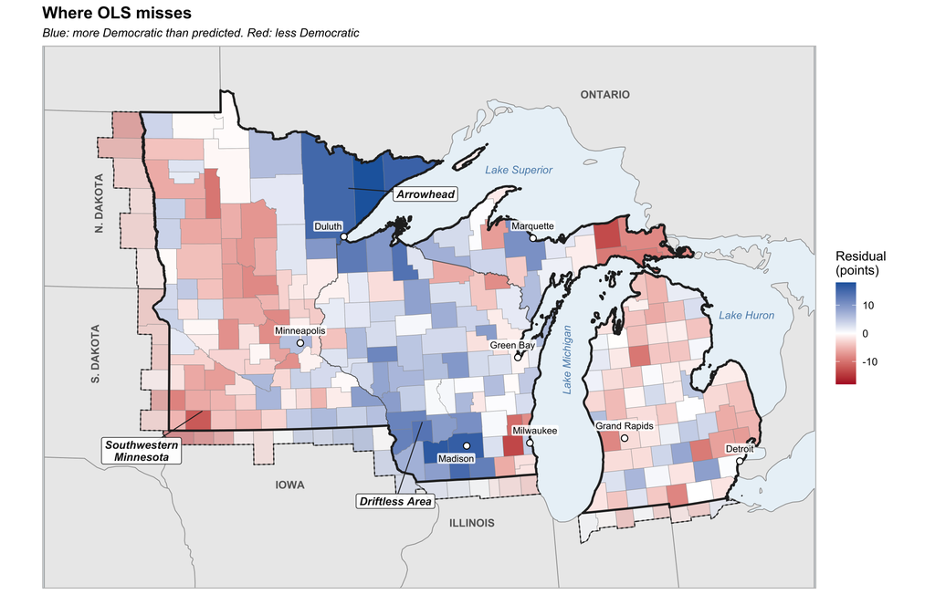

```r
study_area <- study_area %>% mutate(resid_ols = residuals(ols))
resid_limit <- max(abs(study_area$resid_ols))

ggplot() +
  map_under +
  geom_sf(data = filter(study_area, role == "core"), aes(fill = resid_ols), color = "gray60", linewidth = 0.15) +
  geom_sf(data = filter(study_area, role == "guard"), aes(fill = resid_ols), color = "gray60", linewidth = 0.15, alpha = 0.55) +
  map_over +
  city_layers +
  region_layers +
  mw_extent +
  scale_fill_gradient2(low = resid_neg, mid = "white", high = resid_pos, midpoint = 0,
                       limits = c(-resid_limit, resid_limit), name = "Residual\n(points)") +
  labs(title = "Where OLS misses",
       subtitle = "Blue: more Democratic than predicted. Red: less Democratic") +
  map_theme
```

Figure 2: Residuals of the OLS model, in percentage points. Guard counties are faded. The three labeled regions hold the strongest clusters of residuals.

The model under-predicts the Democratic share across southwestern Wisconsin and Minnesota’s Arrowhead, and over-predicts it in southwestern Minnesota. Each is a regional pattern, a group of neighboring counties that share something the five predictors do not capture.

# 3. Which Kind of Spatial Process?

## 3.1 Two Potential Spatial Processes

Clustered residuals can come from at least two quite different spatial processes.

**Spatial error: shared unmeasured influences.** Neighboring counties may share something the model leaves out, such as the political history of the Driftless Area or the labor politics of the Arrowhead, without influencing each other at all. The dependence then lives in the error term:
$$y = X\beta + u, \qquad u = \lambda W u + \varepsilon$$
The error $u$ of each county is partly the average error of its neighbors, $Wu$, plus a new, independent shock $\varepsilon$. The parameter $\lambda$ measures how strongly the unexplained part of the vote is shared among neighbors. In this model the predictors work just as in OLS; only the errors are dependent.

**Spatial lag: spillovers between neighbors.** Alternatively, the vote in one county may influence the vote in neighboring counties, through shared media markets, social networks, commuting, or campaign organizing that crosses county lines. The dependence is then part of how the outcome is produced:
$$y = \rho W y + X\beta + \varepsilon$$
Here $Wy$ is the average Democratic share among each county’s neighbors, and $\rho$ measures how strongly a county’s outcome follows its neighbors’ outcomes. Because each county’s outcome depends on its neighbors’, and theirs depend on it, a change anywhere ripples through the whole network (Section 7).

## 3.2 Lagrange Multiplier Tests

To try and understand which spatial process may be operating in the study region, we can use a **Lagrange multiplier (LM) tests** to ask whether adding a spatial error term or a spatial lag term to the OLS model would improve it. The LM tests are run after the original OLS model is fit and before either spatial model is estimated. There are inf act four tests to consider:

| Diagnostic test | Name in R | Null hypothesis |
| --- | --- | --- |
| LM-error | `RSerr` | No spatial error dependence ($\lambda = 0$), assuming no spatial lag |
| LM-lag | `RSlag` | No spatial lag ($\rho = 0$), assuming no spatial error dependence |
| Robust LM-error | `adjRSerr` | No spatial error dependence, allowing for a local departure toward a spatial lag |
| Robust LM-lag | `adjRSlag` | No spatial lag, allowing for a local departure toward spatial error dependence |

Table 2: The four Lagrange multiplier tests and their null hypotheses.

The two ordinary tests each assume the other kind of dependence is absent. That is a problem, because the two forms leave similar fingerprints in the residuals. A strong error process will often make LM-lag significant too, and the reverse. The **robust** versions adjust each test for the possible presence of the other, so they are the ones to use when considering the models.

A common reading of the robust tests, using 0.05 as a working threshold:

- Robust LM-error significant, robust LM-lag not: investigate the **spatial error** model.
- Robust LM-lag significant, robust LM-error not: investigate the **spatial lag** model.
- Both significant: the tests do not settle it. Compare the size of the two statistics, fit both models, and lean on theory.
- Neither significant: the tests do not support either extension.

Here we use `lm.RStests()` to run the tests on a fitted OLS model for the 2024 election.

```r
# The two ordinary tests and their robust versions
lm_test_names <- c("RSerr", "RSlag", "adjRSerr", "adjRSlag")
lm_test_labels <- c("LM-error", "LM-lag", "Robust LM-error", "Robust LM-lag")

lm_tests <- lm.RStests(ols, lw_queen, test = lm_test_names, spChk = TRUE)

# Collect the statistics and p-values in one table
lm_table <- tibble(Test = lm_test_labels,
                   Statistic = sapply(lm_tests[lm_test_names], function(x) unname(x$statistic)),
                   p = sapply(lm_tests[lm_test_names], function(x) x$p.value))
```

| Test | Statistic | p-value |
| --- | --- | --- |
| LM-error | 173.66 | < 0.001 |
| LM-lag | 55.82 | < 0.001 |
| Robust LM-error | 122.31 | < 0.001 |
| Robust LM-lag | 4.46 | 0.035 |

Table 3: Lagrange multiplier tests on the residuals of the OLS model.

Both ordinary tests are highly significant, as expected when the residuals are this strongly dependent. The robust tests separate the two. Robust LM-error is 122.3 ($p$ < 0.001); robust LM-lag is 4.5 ($p$ = 0.035). Strictly, both robust tests are significant at 0.05, so the rule above does not settle the question. But the evidence is lopsided: the error statistic is many times the lag statistic, and the lag test only just clears the threshold. The tests point toward a **spatial error** process.

## 3.3 Can State Indicators Absorb the Pattern?

Before turning to spatial models, it is worth asking whether a measured regional variable could account for the dependence. States differ in election law, campaign spending, candidates down the ballot, and political culture, and every county in a state shares them. Adding a **dummy variable** for each state gives each state its own intercept. Minnesota is the reference, so each state’s coefficient is its average difference from Minnesota, holding the five predictors constant. Because the model includes the guard counties, the guard states get indicators too.

```r
# Add an indicator for each state, with Minnesota as the reference
study_area <- study_area %>% mutate(state_f = relevel(factor(state_abb), ref = "MN"))
ols_state <- lm(update(model_formula, . ~ . + state_f), data = study_area, na.action = na.fail)

# Repeat the residual Moran test and the LM tests with the same weights
moran_state <- lm.morantest(ols_state, lw_queen, alternative = "two.sided", spChk = TRUE)
lm_tests_state <- lm.RStests(ols_state, lw_queen, test = lm_test_names, spChk = TRUE)
```

|  | OLS Statistic | OLS p-value | OLS with state indicators Statistic | OLS with state indicators p-value |
| --- | --- | --- | --- | --- |
| Residual Moran’s I | 0.501 | < 0.001 | 0.406 | < 0.001 |
| LM-error | 173.660 | < 0.001 | 114.491 | < 0.001 |
| LM-lag | 55.819 | < 0.001 | 39.694 | < 0.001 |
| Robust LM-error | 122.305 | < 0.001 | 75.506 | < 0.001 |
| Robust LM-lag | 4.464 | 0.035 | 0.709 | 0.400 |

Table 4: Residual Moran’s I and Lagrange multiplier tests, without and with state indicators.

With state indicators, Wisconsin counties average 5.9 points more Democratic than comparable Minnesota counties, and Michigan counties 0.9 points more. Residual Moran’s I falls from 0.501 to 0.406, but remains highly significant. State differences explain part of the pattern, but most of it remains: the clusters in Figure 2 are much smaller than states, and a single intercept per state cannot capture the Driftless Area or the Arrowhead.

The robust tests now agree even more clearly. Robust LM-error remains significant ($p$ < 0.001), and robust LM-lag is no longer significant ($p$ = 0.400). Once broad state differences are accounted for, the weak evidence for a lag process largely disappears; what is left looks like shared, unmeasured regional influences.

# 4. The Spatial Error Model

## 4.1 Fitting the Model

The spatial error model is fit with `errorsarlm()` from the `spatialreg` package. It takes the same formula and data as `lm()`, plus the spatial weights. The coefficients and $\lambda$ are estimated together by maximum likelihood.

```r
# Spatial error model: y = Xb + u, u = lambda W u + e
error_model <- errorsarlm(model_formula, data = study_area, listw = lw_queen, na.action = na.fail)
```

The estimated $\lambda$ is 0.717 (standard error 0.048). Values near 0 would mean little dependence in the errors; values near 1, very strong dependence. A county’s unexplained Democratic share closely follows the unexplained share of its neighbors.

A useful way to see what the spatial error model is doing is to rearrange it. Start with the error equation, $u = \lambda W u + \varepsilon$, and move the neighbors’ term to the left-hand side: $u - \lambda W u = \varepsilon$, or more compactly $(I - \lambda W)\,u = \varepsilon$.

The expression $(I - \lambda W)$ is an $n \times n$ matrix with two parts.

- $I$ is the **identity matrix**: 1s on the diagonal and 0s everywhere else. It is the matrix version of the number 1, so multiplying a variable by $I$ leaves it unchanged ($Iu = u$).
- $\lambda W$ is the weights matrix scaled by $\lambda$. With row-standardized weights, $Wu$ is each county’s neighbors’ average error, so $\lambda W u$ is the part of each county’s error that echoes its neighbors.

Read one row at a time, $(I - \lambda W)$ gives a county a weight of 1 on its own value and $-\lambda / k_i$ on each of its $k_i$ neighbors. With $\lambda =$ 0.717, a county with four neighbors gets a weight of 1 on itself and -0.179 on each neighbor. Multiplying by $(I - \lambda W)$ therefore subtracts from each county the part of its value that is shared with its neighbors. It is a **spatial filter**. Applied to the errors, it removes their dependence and leaves only the independent shocks $\varepsilon$.

Because $y = X\beta + u$, applying the same filter to both sides of the model gives
$$(I - \lambda W)\,y = (I - \lambda W)\,X\beta + \varepsilon$$
Each term $(I - \lambda W)z = z - \lambda Wz$ is a **spatially filtered** variable. In this case a county’s value minus $\lambda$ times its neighbors’ average. The spatial error model runs OLS on spatially filtered data. It asks how a county’s Democratic share differs from what its surroundings would lead us to expect, and relates that to how its characteristics differ from its surroundings. That is why $\beta$ keeps its usual OLS meaning: the change in the expected outcome for a one-unit increase in a predictor, holding the others constant.

## 4.2 Coefficients and Standard Errors

Table 5 compares the OLS and SEM regression models.

```r
# Estimates and standard errors for OLS and the spatial error model, side by side
coef_table <- function(est_ols, est_sp) {
  tibble(variable = c("(Intercept)", predictors)) %>%
    mutate(ols_est = est_ols[variable, 1], ols_se = est_ols[variable, 2], ols_p = est_ols[variable, 4],
           sp_est = est_sp[variable, 1], sp_se = est_sp[variable, 2], sp_p = est_sp[variable, 4])
}
error_coefs <- coef_table(coef(summary(ols)), summary(error_model)$Coef)
```

| Term | OLS Estimate | OLS Std. Error | OLS p | Spatial error Estimate | Spatial error Std. Error | Spatial error p |
| --- | --- | --- | --- | --- | --- | --- |
| Intercept | 69.034 | 4.276 | < 0.001 | 75.078 | 4.457 | < 0.001 |
| White non-college share | -0.597 | 0.046 | < 0.001 | -0.597 | 0.037 | < 0.001 |
| Manufacturing share | -0.240 | 0.072 | < 0.001 | -0.256 | 0.065 | < 0.001 |
| Log population density | 1.551 | 0.391 | < 0.001 | 1.792 | 0.425 | < 0.001 |
| Median age | 0.138 | 0.081 | 0.092 | -0.014 | 0.067 | 0.831 |
| Unemployment change | -0.500 | 0.272 | 0.067 | -0.547 | 0.264 | 0.038 |

Table 5: Coefficients of the OLS and spatial error models. The response variable is in percentage points.

Three things are worth noticing.

- **The main relationships hold.** The white non-college share (-0.597 in OLS, -0.597 in the error model) and the manufacturing share remain negative and significant, and log density remains positive and significant.
- **Median age changes most.** In OLS, its coefficient is 0.138 ($p$ = 0.092); in the error model it is -0.014 ($p$ = 0.831). Part of the OLS age association reflected regional clustering: once the model accounts for what neighboring counties share, little age association remains.
- **Standard errors change in both directions.** Because OLS treats dependent observations as independent, its standard errors are unreliable. That does not mean every OLS standard error is too small: here the standard error for log density rises (0.391 to 0.425), while the one for the white non-college share falls (0.046 to 0.037). Unemployment change crosses the 0.05 line ($p$ = 0.067 in OLS, $p$ = 0.038 in the error model), a reminder not to make much of a p-value near the threshold in either model.

## 4.3 Did the SEM Model Remove all the Spatial Dependence?

If the error model captures the spatial dependence, its residuals should no longer cluster. The residuals returned by `errorsarlm()` are the filtered errors $\hat\varepsilon = \hat u - \hat\lambda W \hat u$, the independent shocks left after removing what neighbors share. We describe their spatial pattern with Moran’s I, calculated directly with `moran()` (`lm.morantest()` applies only to OLS models).

```r
# Moran's I of a vector of residuals, with row-standardized weights (the weights sum to n)
residual_moran <- function(r, lw) moran(r, lw, n = length(r), S0 = Szero(lw))$I

study_area <- study_area %>% mutate(resid_error = residuals(error_model))
I_error <- residual_moran(study_area$resid_error, lw_queen)
```

Moran’s I of the residuals falls from 0.501 in OLS to -0.034 in the error model. The spatial error term has absorbed essentially all of the dependence. Figure 3 (Section 5.3) compares the residual maps of all three models.

# 5. The Spatial Lag Model

For completeness, we also fit the spatial lag model to the election data.

## 5.1 Fitting the Model

The spatial lag model is fit with `lagsarlm()`, which takes the same arguments as `errorsarlm()`.

```r
# Spatial lag model: y = rho W y + Xb + e
lag_model <- lagsarlm(model_formula, data = study_area, listw = lw_queen, na.action = na.fail)
```

The estimated $\rho$ is 0.371 (standard error 0.051). Read literally, a county’s Democratic share rises by about 0.37 points for every additional point in its neighbors’ average share, holding its own characteristics constant.

The model cannot be fit by OLS, because the spatial lag $Wy$ is built from the response variable itself. Each county’s outcome helps determine its neighbors’ outcomes, which in turn help determine its own, so $Wy$ is correlated with the error term. `lagsarlm()` estimates $\rho$ and $\beta$ together by maximum likelihood, which handles this simultaneity.

## 5.2 Coefficients

```r
lag_coefs <- coef_table(coef(summary(ols)), summary(lag_model)$Coef)
```

| Term | OLS Estimate | OLS Std. Error | OLS p | Spatial lag Estimate | Spatial lag Std. Error | Spatial lag p |
| --- | --- | --- | --- | --- | --- | --- |
| Intercept | 69.034 | 4.276 | < 0.001 | 58.372 | 4.348 | < 0.001 |
| White non-college share | -0.597 | 0.046 | < 0.001 | -0.554 | 0.042 | < 0.001 |
| Manufacturing share | -0.240 | 0.072 | < 0.001 | -0.249 | 0.065 | < 0.001 |
| Log population density | 1.551 | 0.391 | < 0.001 | 0.851 | 0.365 | 0.020 |
| Median age | 0.138 | 0.081 | 0.092 | 0.046 | 0.073 | 0.531 |
| Unemployment change | -0.500 | 0.272 | 0.067 | -0.496 | 0.244 | 0.042 |

Table 6: Coefficients of the OLS and spatial lag models.

Most coefficients are somewhat smaller in magnitude than in OLS; log density falls from 1.551 to 0.851, and the intercept from 69.0 to 58.4. Part of what OLS attributed to each county’s own characteristics is now carried by its neighbors’ outcomes.

**These coefficients cannot be read like OLS coefficients.** In the lag model, a change in one county’s characteristics changes its own outcome by $\beta$, which changes its neighbors’ outcomes through $\rho Wy$, which feeds back to the county itself. The coefficient $\beta$ is only the first round of that process. Section 7 shows how to calculate the full effect.

## 5.3 Did the Model Remove the Dependence?

```r
study_area <- study_area %>% mutate(resid_lag = residuals(lag_model))
I_lag <- residual_moran(study_area$resid_lag, lw_queen)
```

Moran’s I of the lag model’s residuals is 0.241, down from 0.501 in OLS but far from the -0.034 of the error model. Figure 3 shows why.

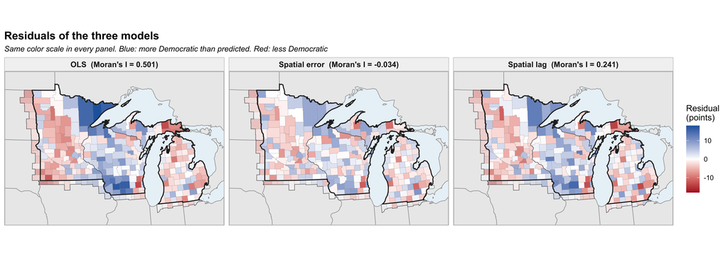

```r
# Stack the residuals of the three models so they can share one map with one color scale
resid_long <- study_area %>%
  dplyr::select(fips, role, OLS = resid_ols, `Spatial error` = resid_error, `Spatial lag` = resid_lag) %>%
  pivot_longer(c(OLS, `Spatial error`, `Spatial lag`), names_to = "model", values_to = "resid") %>%
  st_as_sf() %>%
  mutate(model = factor(model, levels = names(model_colors)),
         label = paste0(model, "  (Moran's I = ",
                        f3(c(OLS = I_ols, `Spatial error` = I_error, `Spatial lag` = I_lag)[as.character(model)]), ")"))

ggplot() +
  map_under +
  geom_sf(data = filter(resid_long, role == "core"), aes(fill = resid), color = "gray60", linewidth = 0.08) +
  geom_sf(data = filter(resid_long, role == "guard"), aes(fill = resid), color = "gray60", linewidth = 0.08, alpha = 0.55) +
  geom_sf(data = states, fill = NA, color = "gray35", linewidth = 0.25) +
  geom_sf(data = core_outline, fill = NA, color = "gray15", linewidth = 0.6) +
  facet_wrap(~ label, ncol = 3) +
  mw_extent +
  scale_fill_gradient2(low = resid_neg, mid = "white", high = resid_pos, midpoint = 0,
                       limits = c(-resid_limit, resid_limit), oob = scales::squish, name = "Residual\n(points)") +
  labs(title = "Residuals of the three models",
       subtitle = "Same color scale in every panel. Blue: more Democratic than predicted. Red: less Democratic") +
  map_theme +
  theme(strip.background = element_rect(fill = "gray95", color = "gray"),
        strip.text = element_text(face = "bold", size = 10))
```

Figure 3: Residuals of the OLS, spatial error, and spatial lag models, in percentage points, on a common color scale. Guard counties are faded.

The lag model shrinks the residuals of every county somewhat, but the blocks of blue in southwestern Wisconsin and the Arrowhead and the block of red in southwestern Minnesota are still visible. The error model’s residuals are smaller and show no regional pattern.

# 6. Comparing the Models

## 6.1 Model Fit

The **Akaike Information Criterion (AIC)** compares models by their likelihood, with a penalty for each estimated parameter:
$$\text{AIC} = 2k - 2\ln\hat{L}$$
Lower is better. AIC can only compare models fitted to the **same response variable and the same observations**, which is true of every model here. A difference of more than about 10 is usually treated as strong evidence for the model with the lower value. For completeness, Table 7 also includes the state-indicator versions of each model, fitted the same way.

```r
# The spatial models with state indicators added
state_formula <- update(model_formula, . ~ . + state_f)
error_state <- errorsarlm(state_formula, data = study_area, listw = lw_queen, na.action = na.fail)
lag_state <- lagsarlm(state_formula, data = study_area, listw = lw_queen, na.action = na.fail)

aic_table <- tibble(
  Model = rep(names(model_colors), times = 2),
  States = rep(c("No", "Yes"), each = 3),
  AIC = c(AIC(ols), AIC(error_model), AIC(lag_model), AIC(ols_state), AIC(error_state), AIC(lag_state)),
  Spatial = c(NA, lambda, rho, NA, error_state$lambda, lag_state$rho),
  `Residual Moran's I` = c(I_ols, I_error, I_lag,
                           residual_moran(residuals(ols_state), lw_queen),
                           residual_moran(residuals(error_state), lw_queen),
                           residual_moran(residuals(lag_state), lw_queen))) %>%
  mutate(`Difference from lowest AIC` = AIC - min(AIC))
```

| Model | State indicators | λ or ρ | AIC | Difference from lowest AIC | Residual Moran’s I |
| --- | --- | --- | --- | --- | --- |
| OLS | No | — | 1806.4 | 137.5 | 0.501 |
| Spatial error | No | 0.717 | 1674.1 | 5.3 | -0.034 |
| Spatial lag | No | 0.371 | 1761.0 | 92.1 | 0.241 |
| OLS | Yes | — | 1763.4 | 94.5 | 0.406 |
| Spatial error | Yes | 0.685 | 1668.9 | 0.0 | -0.027 |
| Spatial lag | Yes | 0.308 | 1731.3 | 62.4 | 0.205 |

Table 7: Fit and residual dependence of the OLS, spatial error, and spatial lag models, without and with state indicators. The spatial parameter is $\lambda$ for the error models and $\rho$ for the lag models.

Without state indicators, the spatial error model has the lowest AIC (1674.1), 87 below the lag model and 132 below OLS. Both spatial models improve on OLS, but the error model by far more. Adding state indicators improves OLS and the lag model considerably but the error model only slightly (5.3 points), because the error term was already capturing most of what states share. The lowest AIC overall belongs to the spatial error model with state indicators.

## 6.2 Choosing a Model

Three kinds of evidence that we produced point to the same course of action.

1. **Diagnostics before fitting:** the robust LM tests favor a spatial error process, and the evidence for a lag process largely disappears once states are accounted for (Tables 3 and 4).
2. **Fit:** the error model has a far lower AIC than the lag model (Table 7).
3. **Residuals:** only the error model removes the spatial dependence; the lag model leaves the regional clusters intact (Figure 3).

The fourth kind of evidence is theory. The clusters in Figure 2 fit a story of **shared regional histories**, such as the Driftless Area’s long-standing rural progressivism and the Arrowhead’s mining and union politics, better than a story of counties actively influencing their neighbors’ votes. None of this proves the error process is the true one: different processes can generate similar data, and the tests and AIC depend on the choice of $W$. But when diagnostics, fit, residuals, and theory agree, we can choose the spatial error model with reasonable confidence.

|  | OLS | Spatial error | Spatial lag |
| --- | --- | --- | --- |
| White non-college share | -0.597 | -0.597 | -0.554 |
| Manufacturing share | -0.240 | -0.256 | -0.249 |
| Log population density | 1.551 | 1.792 | 0.851 |
| Median age | 0.138 | -0.014 | 0.046 |
| Unemployment change | -0.500 | -0.547 | -0.496 |
| λ (error) | — | 0.717 | — |
| ρ (lag) | — | — | 0.371 |
| AIC | 1806.388 | 1674.140 | 1760.964 |
| Residual Moran’s I | 0.501 | -0.034 | 0.241 |

Table 8: Predictor coefficients, spatial parameters, fit, and residual dependence of the three models. A dash marks a parameter that is not part of the model. The lag-model coefficients are not the effects of the predictors (Section 7).

# 7. Direct, Indirect, and Total Effects

Even though the error model is preferred here, the spatial lag model raises an interpretive question that comes up whenever a lag model is the right choice: **what is the effect of a predictor when outcomes spill over between places?**

## 7.1 Why the Coefficient Is Not the Effect

Solving the lag model for $y$ gives
$$E(y \mid X) = (I - \rho W)^{-1} X\beta$$
The matrix $(I - \rho W)^{-1}$ is the **spatial multiplier**. It can be expanded as
$$(I - \rho W)^{-1} = I + \rho W + \rho^2 W^2 + \rho^3 W^3 + \dots$$
which spells out the rounds of the ripple: the change in a county itself ($I$), the change passed to its neighbors ($\rho W$), to its neighbors’ neighbors ($\rho^2 W^2$), and so on, each round smaller than the last because $\rho < 1$. Some of each round also returns to the county where the change began.

So for predictor $k$, the effect of a change in county $j$ on county $i$ is the $(i, j)$ entry of $(I - \rho W)^{-1}\beta_k$. These $n \times n$ effects are summarized by three averages:

- **Direct effect:** the average effect of a change in a county’s predictor on **its own** outcome, including the feedback that returns through its neighbors. It is the average of the diagonal entries.
- **Indirect effect:** the average **combined** effect of that change on the outcomes of **all other** counties. It is the average row sum of the off-diagonal entries, and it includes counties well beyond the immediate neighbors.
- **Total effect:** the direct effect plus the indirect effect.

With row-standardized weights, the total effect is simply $\beta_k / (1 - \rho)$. With $\rho =$ 0.371, every total effect is 1.59 times its coefficient.

## 7.2 One County’s Ripple

To see the multiplier at work, consider a single change. Suppose the population density of Dane County, Wisconsin (home to Madison), doubled, and nothing else changed. Log density would rise by $\ln 2$, and Figure 4 maps the change the lag model predicts in every county’s Democratic share.

```r
# The spatial multiplier for the fitted lag model (a 281 x 281 matrix)
W <- listw2mat(lw_queen)
multiplier <- solve(diag(nrow(W)) - rho * W)

# Effect of doubling Dane County's density on every county: column j of the multiplier, times beta, times ln 2
j <- which(study_area$name == "Dane County, WI")
beta_density <- coef(lag_model)["log_pop_density"]
study_area <- study_area %>% mutate(ripple = multiplier[, j] * beta_density * log(2))

# Sum the effect by order of neighbor: Dane itself, first-order neighbors, second-order, and so on
neighbor_order <- nblag(nb_queen, maxlag = 4)
ripple_by_order <- tibble(
  Order = c("Dane County itself", "First-order neighbors", "Second-order neighbors",
            "Third-order neighbors", "Fourth-order neighbors"),
  Counties = c(1, sapply(1:4, function(k) length(neighbor_order[[k]][[j]]))),
  Change = c(study_area$ripple[j], sapply(1:4, function(k) sum(study_area$ripple[neighbor_order[[k]][[j]]]))))
```

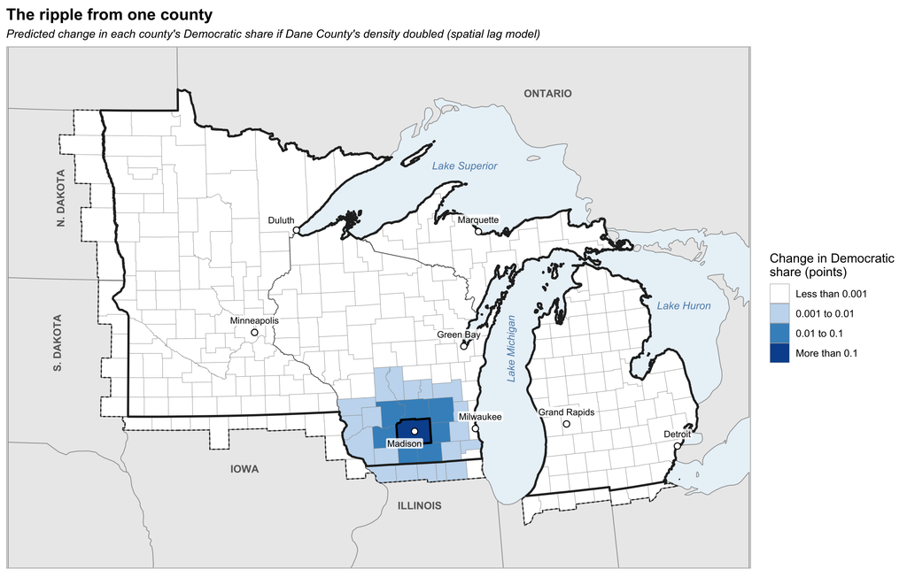

```r
ripple_breaks <- c(-Inf, 0.001, 0.01, 0.1, Inf)
ripple_labels <- c("Less than 0.001", "0.001 to 0.01", "0.01 to 0.1", "More than 0.1")
study_area <- study_area %>% mutate(ripple_class = cut(ripple, ripple_breaks, labels = ripple_labels))
dane <- filter(study_area, name == "Dane County, WI")

ggplot() +
  map_under +
  geom_sf(data = study_area, aes(fill = ripple_class), color = "gray60", linewidth = 0.15) +
  map_over +
  geom_sf(data = dane, fill = NA, color = "black", linewidth = 0.9) +
  city_layers +
  mw_extent +
  scale_fill_manual(values = c("white", continuous_palette[c(2, 4, 5)]), drop = FALSE,
                    name = "Change in Democratic\nshare (points)") +
  labs(title = "The ripple from one county",
       subtitle = "Predicted change in each county's Democratic share if Dane County's density doubled (spatial lag model)") +
  map_theme
```

Figure 4: The change in each county’s predicted Democratic share from a doubling of population density in Dane County alone (outlined), according to the spatial lag model. The classes are on a multiplicative scale: each is ten times the one below.

| Counties affected | Number of counties | Combined change (points) |
| --- | --- | --- |
| Dane County itself | 1 | 0.606 |
| First-order neighbors | 7 | 0.303 |
| Second-order neighbors | 15 | 0.075 |
| Third-order neighbors | 20 | 0.014 |
| Fourth-order neighbors | 13 | 0.001 |

Table 9: The predicted change in Democratic share from a doubling of Dane County’s density, summed over Dane County and each order of its neighbors.

The first round of the effect, $\beta \ln 2$, is 0.590 points in Dane County alone. With feedback from its neighbors, Dane County’s own change is 0.606 points. Its 7 immediate neighbors gain 0.303 points between them, its second-order neighbors 0.075, and the effect fades quickly beyond that. Summed over every county, the doubling changes the region’s predicted Democratic share by 0.998 points, about 1.7 times what the coefficient alone would suggest.

## 7.3 Average Impacts

`impacts()` calculates the direct, indirect, and total effects of every predictor, averaged over all counties. The point estimates come from the fitted model. Because $\rho$ and $\beta$ are estimated with uncertainty, `impacts()` also draws `R` simulated sets of parameter values from their estimated sampling distribution and recalculates the effects for each draw; the spread of the draws gives a standard error for each effect.

```r
# Direct, indirect, and total effects, with 1,000 simulated draws for their uncertainty
set.seed(172)
lag_impacts <- impacts(lag_model, listw = lw_queen, R = 1000)

impact_types <- c("direct", "indirect", "total")
impact_terms <- names(coef(lag_model))[!names(coef(lag_model)) %in% c("rho", "(Intercept)")]

# Point estimates from the fitted model; standard errors and 95% intervals from the draws
impacts_long <- bind_rows(lapply(impact_types, function(type) {
  draws <- as.matrix(lag_impacts$sres[[type]])
  tibble(Term = impact_terms,
         Effect = type,
         Estimate = as.numeric(lag_impacts$res[[type]]),
         SE = apply(draws, 2, sd),
         Lower = apply(draws, 2, quantile, probs = 0.025),
         Upper = apply(draws, 2, quantile, probs = 0.975))
}))
```

| Predictor | Coefficient | Direct Estimate | Direct Std. Error | Indirect Estimate | Indirect Std. Error | Total Estimate | Total Std. Error |
| --- | --- | --- | --- | --- | --- | --- | --- |
| White non-college share | -0.554 | -0.572 | 0.043 | -0.309 | 0.063 | -0.880 | 0.084 |
| Manufacturing share | -0.249 | -0.256 | 0.064 | -0.138 | 0.047 | -0.395 | 0.106 |
| Log population density | 0.851 | 0.878 | 0.377 | 0.474 | 0.212 | 1.352 | 0.573 |
| Median age | 0.046 | 0.047 | 0.076 | 0.026 | 0.042 | 0.073 | 0.117 |
| Unemployment change | -0.496 | -0.511 | 0.252 | -0.276 | 0.155 | -0.787 | 0.399 |

Table 10: The lag-model coefficient and the direct, indirect, and total effects of each predictor, in percentage points of Democratic share per unit of the predictor. Standard errors come from 1,000 simulated draws.

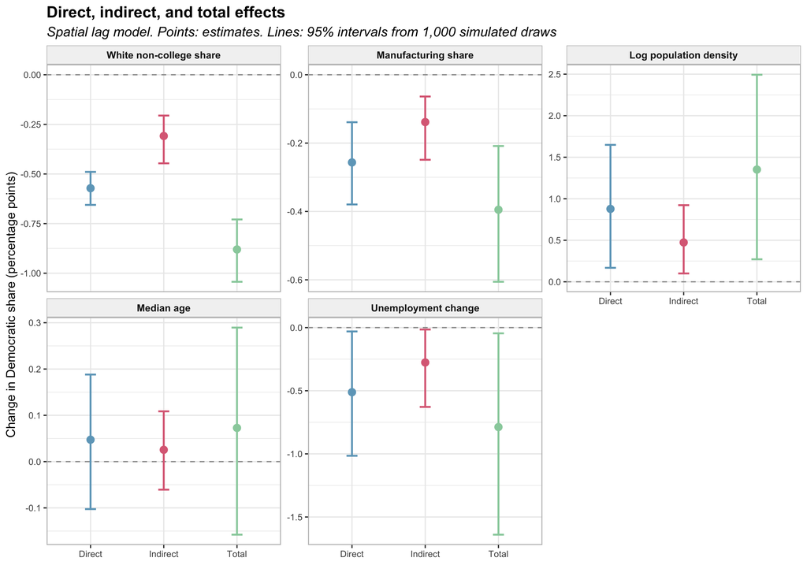

```r
impacts_long %>%
  mutate(Effect = factor(Effect, levels = impact_types, labels = c("Direct", "Indirect", "Total")),
         Term = factor(var_labels[Term], levels = var_labels[impact_terms])) %>%
  ggplot(aes(x = Effect, y = Estimate, color = Effect)) +
  geom_hline(yintercept = 0, color = "gray60", linetype = "dashed", linewidth = 0.5) +
  geom_errorbar(aes(ymin = Lower, ymax = Upper), width = 0.15, linewidth = 0.8) +
  geom_point(size = 2.8) +
  facet_wrap(~ Term, ncol = 3, scales = "free_y") +
  scale_color_manual(values = c(Direct = "#6EA6C3", Indirect = "#DC6D85", Total = "#99CFAB")) +
  themeGrid +
  theme(legend.position = "none",
        strip.background = element_rect(fill = "grey95", color = "grey"),
        strip.text = element_text(face = "bold"),
        axis.title.x = element_blank()) +
  labs(title = "Direct, indirect, and total effects",
       subtitle = "Spatial lag model. Points: estimates. Lines: 95% intervals from 1,000 simulated draws",
       y = "Change in Democratic share (percentage points)")
```

Figure 5: Direct, indirect, and total effects of each predictor in the spatial lag model. Each panel has its own vertical scale.

## 7.4 Reading the Effects

Take the white non-college share as an example, and imagine raising it by one percentage point in a single county, holding everything else constant.

- The **direct effect** is -0.572 points: on average, that county’s own predicted Democratic share falls by 0.572 points. This is slightly larger in magnitude than the coefficient (-0.554), because part of the change returns to the county through its neighbors.
- The **indirect effect** is -0.309 points: on average, the predicted Democratic share of all other counties falls by a **combined** 0.309 points. This is a total across many counties, not a change in any one neighbor.
- The **total effect** is -0.880 points, the sum of the two.

The indirect effect is 35.1 percent of the total. In a spatial lag model this share is the **same for every predictor**, because every predictor’s effect passes through the same multiplier $(I - \rho W)^{-1}$; it depends only on $\rho$ and $W$. The model has no way to say that one characteristic spills over more than another.

Two cautions apply.

- **Impacts belong to the lag model.** In the spatial error model, a change in one county’s predictors affects only that county’s expected outcome, so the direct effect is $\beta$ and there is no indirect effect. Since the evidence in Section 6 favors the error model, the spillovers estimated here are what the data would imply *if* the lag process were the right one, not findings in their own right.
- **Spillovers between counties are not behavior of individuals.** An indirect effect says that counties near places with more white non-college adults vote less Democratic than the model would otherwise predict. It does not say why, and it says nothing about how any individual voter, in either county, voted.

# 8. Summary

- When OLS residuals are spatially dependent, spatial regression models represent the dependence directly. The **spatial error** model puts it in the errors (shared, unmeasured influences); the **spatial lag** model puts it in the outcome (spillovers between neighbors).
- The **robust Lagrange multiplier tests** help choose between them before either is fitted. For the Upper Midwest vote they favor a spatial error process, more clearly still once **state indicators** absorb broad state differences.
- The **spatial error model** (λ = 0.72) has a far lower AIC than OLS or the lag model and leaves residuals with no spatial pattern. Its coefficients keep their OLS meaning; the association with median age disappears once shared regional influences are accounted for.
- The **spatial lag model** (ρ = 0.37) improves on OLS but leaves the regional clusters in place.
- In a lag model, a coefficient is not the effect of its predictor. The **spatial multiplier** spreads each change across the network, and `impacts()` separates the **direct**, **indirect**, and **total** effects, with simulated standard errors.
- Diagnostics, fit, residuals, and theory together support the spatial error model here. None of them alone can prove which process produced the data, and all of them depend on the definition of neighbors.

**Considerations**

1. The spatial error model removed the dependence from the residuals, but it did not explain it: $\lambda$ says that neighbors share *something*, not what. Choose one of the three regions labeled in Figure 2 and propose a variable that might explain it. If you added it to the model, what would you expect to happen to $\lambda$?
2. Both robust LM tests were significant before state indicators were added. Using Tables 3 and 4, explain why the evidence still favored one model over the other, and why it would be a mistake to rely on the ordinary (non-robust) tests.
3. The indirect share of the total effect was identical for all five predictors (Section 7.4). Why? Describe a situation in which you would expect one county characteristic to spill over to neighboring counties more than another, and explain why the spatial lag model could not capture it.
4. All of these results depend on queen contiguity. How might the LM tests, $\lambda$, $\rho$, or the impacts change if neighbors were defined as each county’s six nearest counties instead?

### Declaration of Generative AI and AI-Assisted Technologies

The author used Anthropic’s Claude (Opus 5.5) when developing this demonstration. A connection to RStudio through the ClaudeR package was used to draft and debug the R code. The author subsequently reviewed and edited all of that output and takes full responsibility for the content.